# Question 1: (Visualization)

## Spark Setup

```python
# Run this cell to import pyspark and to define start_spark() and stop_spark()

import findspark

findspark.init()

import getpass
import pandas
import pyspark
import random
import re

from IPython.display import display, HTML
from pyspark import SparkContext
from pyspark.sql import SparkSession


# Constants used to interact with Azure Blob Storage using the hdfs command or Spark

global username

username = re.sub('@.*', '', getpass.getuser())

global azure_account_name
global azure_data_container_name # where data is stored for the assignment
global azure_user_container_name # where users who are doing the assignment can save their outputs
global azure_user_token # which is required for read/write access


# These are pre-defined and you don't need to change this
azure_account_name = "madsstorage002"
azure_data_container_name = "campus-data"
azure_user_container_name = "campus-user"
azure_user_token = r""


# Functions used below

def dict_to_html(d):
    """Convert a Python dictionary into a two column table for display.
    """

    html = []

    html.append(f'<table width="100%" style="width:100%; font-family: monospace;">')
    for k, v in d.items():
        html.append(f'<tr><td style="text-align:left;">{k}</td><td>{v}</td></tr>')
    html.append(f'</table>')

    return ''.join(html)


def show_as_html(df, n=20):
    """Leverage existing pandas jupyter integration to show a spark dataframe as html.

    Args:
        n (int): number of rows to show (default: 20)
    """

    display(df.limit(n).toPandas())


def display_spark():
    """Display the status of the active Spark session if one is currently running.
    """

    if 'spark' in globals() and 'sc' in globals():

        name = sc.getConf().get("spark.app.name")

        html = [
            f'<p><b>Spark</b></p>',
            f'<p>The spark session is <b><span style="color:green">active</span></b>, look for <code>{name}</code> under the running applications section in the Spark UI.</p>',
            f'<ul>',
            f'<li><a href="http://localhost:{sc.uiWebUrl.split(":")[-1]}" target="_blank">Spark Application UI</a></li>',
            f'</ul>',
            f'<p><b>Config</b></p>',
            dict_to_html(dict(sc.getConf().getAll())),
            f'<p><b>Notes</b></p>',
            f'<ul>',
            f'<li>The spark session <code>spark</code> and spark context <code>sc</code> global variables have been defined by <code>start_spark()</code>.</li>',
            f'<li>Please run <code>stop_spark()</code> before closing the notebook or restarting the kernel or kill <code>{name}</code> by hand using the link in the Spark UI.</li>',
            f'</ul>',
        ]
        display(HTML(''.join(html)))

    else:

        html = [
            f'<p><b>Spark</b></p>',
            f'<p>The spark session is <b><span style="color:red">stopped</span></b>, confirm that <code>{username} (notebook)</code> is under the completed applications section in the Spark UI.</p>',
            f'<ul>',
            f'<li><a href="http://mathmadslinux2p.canterbury.ac.nz:8080/" target="_blank">Spark UI</a></li>',
            f'</ul>',
        ]
        display(HTML(''.join(html)))


# Functions to start and stop spark

def start_spark(executor_instances=2, executor_cores=1, worker_memory=1, master_memory=1):
    """Start a new Spark session and define globals for SparkSession (spark) and SparkContext (sc).

    Args:
        executor_instances (int): number of executors (default: 2)
        executor_cores (int): number of cores per executor (default: 1)
        worker_memory (float): worker memory (default: 1)
        master_memory (float): master memory (default: 1)
    """

    global spark
    global sc

    cores = executor_instances * executor_cores
    partitions = cores * 4
    port = 4000 + random.randint(1, 999)

    spark = (
        SparkSession.builder
        .config("spark.driver.extraJavaOptions", f"-Dderby.system.home=/tmp/{username}/spark/")
        .config("spark.dynamicAllocation.enabled", "false")
        .config("spark.executor.instances", str(executor_instances))
        .config("spark.executor.cores", str(executor_cores))
        .config("spark.cores.max", str(cores))
        .config("spark.driver.memory", f'{master_memory}g')
        .config("spark.executor.memory", f'{worker_memory}g')
        .config("spark.driver.maxResultSize", "0")
        .config("spark.sql.shuffle.partitions", str(partitions))
        .config("spark.kubernetes.container.image", "madsregistry001.azurecr.io/hadoop-spark:v3.3.5-openjdk-8")
        .config("spark.kubernetes.container.image.pullPolicy", "IfNotPresent")
        .config("spark.kubernetes.memoryOverheadFactor", "0.3")
        .config("spark.memory.fraction", "0.1")
        .config(f"fs.azure.sas.{azure_user_container_name}.{azure_account_name}.blob.core.windows.net",  azure_user_token)
        .config("spark.app.name", f"{username} (notebook)")
        .getOrCreate()
    )
    sc = SparkContext.getOrCreate()

    display_spark()


def stop_spark():
    """Stop the active Spark session and delete globals for SparkSession (spark) and SparkContext (sc).
    """

    global spark
    global sc

    if 'spark' in globals() and 'sc' in globals():

        spark.stop()

        del spark
        del sc

    display_spark()


# Make css changes to improve spark output readability

html = [
    '<style>',
    'pre { white-space: pre !important; }',
    'table.dataframe td { white-space: nowrap !important; }',
    'table.dataframe thead th:first-child, table.dataframe tbody th { display: none; }',
    '</style>',
]
display(HTML(''.join(html)))
```

```python
# Checking If a Spark Session is already in progress
from pyspark.sql import SparkSession

# Safely check for an active Spark session
active_session = SparkSession.getActiveSession()

if active_session is not None:
    print(f"Spark session is RUNNING. App Name: {active_session.sparkContext.appName}")
else:
    print("No Spark session is running. Starting Spark")
    start_spark(executor_instances=4, executor_cores=2, worker_memory=4, master_memory=4)
```

```
Spark session is RUNNING. App Name: ama778 (notebook)
```

## Configuring Paths: "daily" & "stations"

```python
DATA_PATH = (
    f"wasbs://{azure_data_container_name}"
    f"@{azure_account_name}.blob.core.windows.net/"
    "ghcnd"
)

DAILY_PATH = f"{DATA_PATH}/daily"

#daily_2026_path = f"{DAILY_PATH}/2026.csv.gz"

print(DAILY_PATH)
```

```
wasbs://campus-data@madsstorage002.blob.core.windows.net/ghcnd/daily
```

```python
STATIONS_PATH = (
    f"wasbs://{azure_user_container_name}"
    f"@{azure_account_name}.blob.core.windows.net/"
    f"{username}/stations_final"
)

print(STATIONS_PATH)
```

```
wasbs://campus-user@madsstorage002.blob.core.windows.net/ama778/stations_final
```

```python
!hdfs dfs -ls "$DATA_PATH"
```

```
Found 5 items
drwxrwxrwx   -          0 1970-01-01 12:00 wasbs://campus-data@madsstorage002.blob.core.windows.net/ghcnd/daily
-rwxrwxrwx   1       3659 2026-08-05 14:34 wasbs://campus-data@madsstorage002.blob.core.windows.net/ghcnd/ghcnd-countries.txt
-rwxrwxrwx   1   35991182 2026-08-05 14:34 wasbs://campus-data@madsstorage002.blob.core.windows.net/ghcnd/ghcnd-inventory.txt
-rwxrwxrwx   1       1086 2026-08-05 14:34 wasbs://campus-data@madsstorage002.blob.core.windows.net/ghcnd/ghcnd-states.txt
-rwxrwxrwx   1   11395086 2026-08-05 14:34 wasbs://campus-data@madsstorage002.blob.core.windows.net/ghcnd/ghcnd-stations.txt
```

```python
!hdfs dfs -ls "wasbs://campus-user@madsstorage002.blob.core.windows.net/ama778"
```

```
Found 9 items
-rwxrwxrwx   1                            6 2026-07-22 09:16 wasbs://campus-user@madsstorage002.blob.core.windows.net/ama778/ama778
drwxr-xr-x   - ama778 supergroup          0 2026-08-13 17:09 wasbs://campus-user@madsstorage002.blob.core.windows.net/ama778/enriched_stations
drwxr-xr-x   - ama778 supergroup          0 2026-09-02 14:16 wasbs://campus-user@madsstorage002.blob.core.windows.net/ama778/nz_country_monthly_tmin_tmax
drwxr-xr-x   - ama778 supergroup          0 2026-09-02 14:16 wasbs://campus-user@madsstorage002.blob.core.windows.net/ama778/nz_monthly_tmin_tmax
drwxr-xr-x   - ama778 supergroup          0 2026-09-07 16:55 wasbs://campus-user@madsstorage002.blob.core.windows.net/ama778/nz_station_pair_distances
drwxr-xr-x   - ama778 supergroup          0 2026-09-08 13:41 wasbs://campus-user@madsstorage002.blob.core.windows.net/ama778/rainfall_year_country
drwxr-xr-x   - ama778 supergroup          0 2026-09-04 16:34 wasbs://campus-user@madsstorage002.blob.core.windows.net/ama778/rainfall_year_country_mm
drwxr-xr-x   - ama778 supergroup          0 2026-08-11 13:22 wasbs://campus-user@madsstorage002.blob.core.windows.net/ama778/stations
drwxr-xr-x   - ama778 supergroup          0 2026-08-21 12:20 wasbs://campus-user@madsstorage002.blob.core.windows.net/ama778/stations_final
```

## Question 1: Part (a)

### Constructing list of required files for "daily"

```python
years = list(range(1763, 2027))

daily_paths = [
    f"{DAILY_PATH}/{year}.csv.gz"
    for year in years
]

print(len(daily_paths))
print(daily_paths[:3])
print(daily_paths[-3:])
```

```
264
['wasbs://campus-data@madsstorage002.blob.core.windows.net/ghcnd/daily/1763.csv.gz', 'wasbs://campus-data@madsstorage002.blob.core.windows.net/ghcnd/daily/1764.csv.gz', 'wasbs://campus-data@madsstorage002.blob.core.windows.net/ghcnd/daily/1765.csv.gz']
['wasbs://campus-data@madsstorage002.blob.core.windows.net/ghcnd/daily/2024.csv.gz', 'wasbs://campus-data@madsstorage002.blob.core.windows.net/ghcnd/daily/2025.csv.gz', 'wasbs://campus-data@madsstorage002.blob.core.windows.net/ghcnd/daily/2026.csv.gz']
```

### Reading files

```python
daily_all = spark.read.text(daily_paths)

daily_all.printSchema()
daily_all.show(10, truncate=False)
```

```
root
 |-- value: string (nullable = true)

+-------------------------------------+
|value                                |
+-------------------------------------+
|US1ALJF0004,20100101,PRCP,5,,,N,0700 |
|US1ALJF0007,20100101,PRCP,8,,,N,0700 |
|US1ALJF0011,20100101,PRCP,8,,,N,0724 |
|US1ALJF0024,20100101,PRCP,8,,,N,0800 |
|US1ALJF0025,20100101,PRCP,15,,,N,0700|
|US1ALJF0033,20100101,DAPR,5,,,N,0000 |
|US1ALJF0033,20100101,MDPR,89,,,N,0000|
|US1ALJF0034,20100101,PRCP,5,,,N,0700 |
|US1ALJF0035,20100101,PRCP,15,,,N,0700|
|US1ALJF0036,20100101,PRCP,10,,,N,0700|
+-------------------------------------+
only showing top 10 rows
```

```python
stations = spark.read.parquet(STATIONS_PATH)

stations.printSchema()
stations.count()
```

```
root
 |-- ID: string (nullable = true)
 |-- LATITUDE: double (nullable = true)
 |-- LONGITUDE: double (nullable = true)
 |-- ELEVATION: double (nullable = true)
 |-- STATE: string (nullable = true)
 |-- NAME: string (nullable = true)
 |-- GSN_FLAG: string (nullable = true)
 |-- HCN_CRN_FLAG: string (nullable = true)
 |-- WMO_ID: string (nullable = true)
 |-- COUNTRY_NAME: string (nullable = true)
 |-- STATE_NAME: string (nullable = true)
 |-- ELEMENTS: array (nullable = true)
 |    |-- element: string (containsNull = true)
 |-- FIRST_YEAR: integer (nullable = true)
 |-- LAST_YEAR: integer (nullable = true)
 |-- ACTIVE_2026: boolean (nullable = true)
 |-- CORE_ELEMENT_COUNT: integer (nullable = true)
 |-- OTHER_ELEMENT_COUNT: integer (nullable = true)
 |-- COUNTRY_CODE: string (nullable = true)
```

```
132501
```

### Parsing the required fields from "daily"

```python
from pyspark.sql.functions import split, col

daily_parsed = daily_all.select(
    split(col("value"), ",").getItem(0).alias("ID"),
    split(col("value"), ",").getItem(1).alias("DATE"),
    split(col("value"), ",").getItem(2).alias("ELEMENT"),
    split(col("value"), ",").getItem(3).alias("VALUE")
)

daily_parsed.show(10, truncate=False)
```

```
+-----------+--------+-------+-----+
|ID         |DATE    |ELEMENT|VALUE|
+-----------+--------+-------+-----+
|US1ALJF0004|20100101|PRCP   |5    |
|US1ALJF0007|20100101|PRCP   |8    |
|US1ALJF0011|20100101|PRCP   |8    |
|US1ALJF0024|20100101|PRCP   |8    |
|US1ALJF0025|20100101|PRCP   |15   |
|US1ALJF0033|20100101|DAPR   |5    |
|US1ALJF0033|20100101|MDPR   |89   |
|US1ALJF0034|20100101|PRCP   |5    |
|US1ALJF0035|20100101|PRCP   |15   |
|US1ALJF0036|20100101|PRCP   |10   |
+-----------+--------+-------+-----+
only showing top 10 rows
```

### Creating NZ station lookup

```python
nz_station_ids = (
    stations
    .filter(col("COUNTRY_NAME") == "New Zealand")
    .select("ID")
    .distinct()
)

print("NZ stations:", nz_station_ids.count())
```

```
[Stage 258:===================================>                     (5 + 3) / 8]
```

```
NZ stations: 15
```

### Filter daily to NZ + TMIN/TMAX

```python
nz_tmin_tmax = (
    daily_parsed
    .join(
        nz_station_ids,
        on="ID",
        how="left_semi"
    )
    .filter(
        col("ELEMENT").isin("TMIN", "TMAX")
    )
)

nz_tmin_tmax.show(20, truncate=False)
```

```
+-----------+--------+-------+-----+
|ID         |DATE    |ELEMENT|VALUE|
+-----------+--------+-------+-----+
|NZ000093292|20100101|TMAX   |297  |
|NZ000093292|20100101|TMIN   |74   |
|NZ000093417|20100101|TMAX   |180  |
|NZ000093417|20100101|TMIN   |125  |
|NZ000093844|20100101|TMAX   |232  |
|NZ000093844|20100101|TMIN   |96   |
|NZ000933090|20100101|TMAX   |197  |
|NZ000933090|20100101|TMIN   |82   |
|NZ000936150|20100101|TMAX   |324  |
|NZM00093110|20100101|TMAX   |215  |
|NZM00093110|20100101|TMIN   |153  |
|NZM00093439|20100101|TMAX   |204  |
|NZM00093439|20100101|TMIN   |134  |
|NZM00093678|20100101|TMAX   |242  |
|NZM00093678|20100101|TMIN   |94   |
|NZM00093781|20100101|TMAX   |324  |
|NZ000093292|20100102|TMAX   |302  |
|NZ000093292|20100102|TMIN   |180  |
|NZ000093417|20100102|TMAX   |181  |
|NZ000093417|20100102|TMIN   |153  |
+-----------+--------+-------+-----+
only showing top 20 rows
```

### Counting number of observations for NZ

```python
nz_tmin_tmax_count = nz_tmin_tmax.count()

print("Total NZ TMIN/TMAX observations:", nz_tmin_tmax_count)
```

```
[Stage 271:====================================================>(107 + 1) / 108]
```

```
Total NZ TMIN/TMAX observations: 500840
```

### Counting number of years covered

```python
nz_years = (
    nz_tmin_tmax
    .select(col("DATE").substr(1, 4).alias("YEAR"))
    .distinct()
    .orderBy("YEAR")
)

print("Number of years covered:", nz_years.count())

nz_years.show(300, truncate=False)
```

```
Number of years covered: 87
```

```
[Stage 286:====================================================>(107 + 1) / 108]
```

```
+----+
|YEAR|
+----+
|1940|
|1941|
|1942|
|1943|
|1944|
|1945|
|1946|
|1947|
|1948|
|1949|
|1950|
|1951|
|1952|
|1953|
|1954|
|1955|
|1956|
|1957|
|1958|
|1959|
|1960|
|1961|
|1962|
|1963|
|1964|
|1965|
|1966|
|1967|
|1968|
|1969|
|1970|
|1971|
|1972|
|1973|
|1974|
|1975|
|1976|
```

[output cut: 36 more lines]

```
|2013|
|2014|
|2015|
|2016|
|2017|
|2018|
|2019|
|2020|
|2021|
|2022|
|2023|
|2024|
|2025|
|2026|
+----+
```

### Checking for missing dates

```python
nz_dates = (
    nz_tmin_tmax
    .select("DATE")
    .distinct()
    .orderBy("DATE")
)

print("Number of unique dates:", nz_dates.count())

nz_dates.show(20, truncate=False)
```

```
Number of unique dates: 31514
```

```
[Stage 52:=====================================================>(107 + 1) / 108]
```

```
+--------+
|DATE    |
+--------+
|19400308|
|19400309|
|19400310|
|19400311|
|19400312|
|19400313|
|19400314|
|19400315|
|19400316|
|19400317|
|19400318|
|19400319|
|19400320|
|19400321|
|19400322|
|19400323|
|19400324|
|19400325|
|19400326|
|19400327|
+--------+
only showing top 20 rows
```

### Finding the date range

```python
from pyspark.sql.functions import min, max, to_date, datediff

date_range = (
    nz_tmin_tmax
    .select(
        to_date(col("DATE"), "yyyyMMdd").alias("DATE")
    )
    .agg(
        min("DATE").alias("MIN_DATE"),
        max("DATE").alias("MAX_DATE")
    )
)

date_range.show()
```

```
[Stage 58:=====================================================>(107 + 1) / 108]
```

```
+----------+----------+
|  MIN_DATE|  MAX_DATE|
+----------+----------+
|1940-03-08|2026-08-01|
+----------+----------+
```

### Calculating how many calendar days should exist

```python
expected_days = (
    date_range
    .select(
        (datediff(col("MAX_DATE"), col("MIN_DATE")) + 1)
        .alias("EXPECTED_DAYS")
    )
)

expected_days.show()
```

```
[Stage 64:=====================================================>(107 + 1) / 108]
```

```
+-------------+
|EXPECTED_DAYS|
+-------------+
|        31558|
+-------------+
```

### Finding the actual missing date

```python
from pyspark.sql.functions import sequence, explode

all_dates = (
    date_range
    .select(
        explode(
            sequence(
                col("MIN_DATE"),
                col("MAX_DATE")
            )
        ).alias("DATE")
    )
)

actual_dates = (
    nz_tmin_tmax
    .select(
        to_date(col("DATE"), "yyyyMMdd").alias("DATE")
    )
    .distinct()
)
missing_dates = (
    all_dates
    .join(
        actual_dates,
        on="DATE",
        how="left_anti"
    )
    .orderBy("DATE")
)
```

```python
print("Number of missing dates:", missing_dates.count())

missing_dates.show(50, truncate=False)
```

```
Number of missing dates: 44
```

```
[Stage 87:=====================================================>(107 + 1) / 108]
```

```
+----------+
|DATE      |
+----------+
|2006-01-29|
|2007-08-28|
|2012-07-07|
|2014-12-18|
|2014-12-19|
|2015-05-19|
|2015-05-20|
|2015-05-21|
|2015-05-22|
|2015-05-23|
|2015-05-24|
|2015-05-25|
|2015-05-26|
|2018-04-21|
|2018-09-17|
|2019-02-16|
|2019-02-17|
|2019-02-18|
|2021-02-11|
|2021-02-12|
|2021-02-20|
|2023-06-15|
|2023-07-13|
|2024-03-28|
|2024-03-29|
|2024-03-30|
|2024-03-31|
|2024-05-01|
|2024-08-12|
|2024-11-18|
|2024-11-19|
|2024-11-20|
|2024-11-21|
|2024-12-01|
|2025-08-30|
|2025-08-31|
|2025-09-01|
|2025-09-02|
|2026-03-27|
|2026-03-28|
|2026-03-29|
|2026-03-30|
|2026-03-31|
|2026-04-01|
+----------+
```

The important point is that we're not saying individual stations have complete coverage. We're saying that on these 44 dates, there was no TMIN/TMAX observation anywhere among the NZ stations in our filtered dataset.

```
Q1(a) — Final results
Question	                    Result
Total TMIN/TMAX observations	500,840
Years covered	                87 years
Period covered	                1940–2026
First observation	            1940-03-08
Last observation	            2026-08-01
Expected calendar days	        31,558
Actual dates with observations	31,514
Dates with no observations	    44
```

### Question 1(a): Answer

There are 500,840 TMIN and TMAX observations for New Zealand stations, covering 87 years from 1940 to 2026. The observations range from 8 March 1940 to 1 August 2026. There are 44 dates with no TMIN or TMAX observations reported by any of the NZ stations, so there are some gaps in the data.

## Question 1: Part (b)

### Converting DATE and VALUE to appropriate data types

```python
from pyspark.sql.functions import to_date, col

nz_climate_clean = (
    nz_tmin_tmax
    .withColumn(
        "DATE",
        to_date(col("DATE"), "yyyyMMdd")
    )
    .withColumn(
        "VALUE",
        col("VALUE").cast("double")
    )
)

nz_climate_clean.printSchema()

nz_climate_clean.show(10, truncate=False)
```

```
root
 |-- ID: string (nullable = true)
 |-- DATE: date (nullable = true)
 |-- ELEMENT: string (nullable = true)
 |-- VALUE: double (nullable = true)
```

```
+-----------+----------+-------+-----+
|ID         |DATE      |ELEMENT|VALUE|
+-----------+----------+-------+-----+
|NZ000093292|2010-01-01|TMAX   |297.0|
|NZ000093292|2010-01-01|TMIN   |74.0 |
|NZ000093417|2010-01-01|TMAX   |180.0|
|NZ000093417|2010-01-01|TMIN   |125.0|
|NZ000093844|2010-01-01|TMAX   |232.0|
|NZ000093844|2010-01-01|TMIN   |96.0 |
|NZ000933090|2010-01-01|TMAX   |197.0|
|NZ000933090|2010-01-01|TMIN   |82.0 |
|NZ000936150|2010-01-01|TMAX   |324.0|
|NZM00093110|2010-01-01|TMAX   |215.0|
+-----------+----------+-------+-----+
only showing top 10 rows
```

### Aggregating to monthly averages

```python
from pyspark.sql.functions import date_trunc, avg

nz_monthly = (
    nz_climate_clean
    .withColumn(
        "YEAR_MONTH",
        date_trunc("month", col("DATE"))
    )
    .withColumn(
        "TEMP_C",
        col("VALUE") / 10
    )
    .groupBy(
        "ID",
        "YEAR_MONTH",
        "ELEMENT"
    )
    .agg(
        avg("TEMP_C").alias("AVG_TEMP_C")
    )
    .orderBy(
        "ID",
        "YEAR_MONTH",
        "ELEMENT"
    )
)

nz_monthly.show(20, truncate=False)
```

```
[Stage 102:====================================================>(107 + 1) / 108]
```

```
+-----------+-------------------+-------+------------------+
|ID         |YEAR_MONTH         |ELEMENT|AVG_TEMP_C        |
+-----------+-------------------+-------+------------------+
|NZ000093012|1966-01-01 00:00:00|TMAX   |22.30869565217391 |
|NZ000093012|1966-01-01 00:00:00|TMIN   |16.75666666666667 |
|NZ000093012|1966-02-01 00:00:00|TMAX   |24.464000000000002|
|NZ000093012|1966-02-01 00:00:00|TMIN   |18.007692307692306|
|NZ000093012|1966-03-01 00:00:00|TMAX   |22.51290322580645 |
|NZ000093012|1966-03-01 00:00:00|TMIN   |15.582758620689658|
|NZ000093012|1966-04-01 00:00:00|TMAX   |19.630769230769232|
|NZ000093012|1966-04-01 00:00:00|TMIN   |11.87857142857143 |
|NZ000093012|1966-05-01 00:00:00|TMAX   |15.82413793103448 |
|NZ000093012|1966-05-01 00:00:00|TMIN   |8.10909090909091  |
|NZ000093012|1966-06-01 00:00:00|TMAX   |14.457692307692309|
|NZ000093012|1966-06-01 00:00:00|TMIN   |7.391666666666667 |
|NZ000093012|1966-07-01 00:00:00|TMAX   |13.559259259259253|
|NZ000093012|1966-07-01 00:00:00|TMIN   |7.342105263157895 |
|NZ000093012|1966-08-01 00:00:00|TMAX   |13.630769230769236|
|NZ000093012|1966-08-01 00:00:00|TMIN   |6.052380952380953 |
|NZ000093012|1966-09-01 00:00:00|TMAX   |15.419999999999998|
|NZ000093012|1966-09-01 00:00:00|TMIN   |9.107692307692307 |
|NZ000093012|1966-10-01 00:00:00|TMAX   |17.376923076923074|
|NZ000093012|1966-10-01 00:00:00|TMIN   |9.933333333333337 |
+-----------+-------------------+-------+------------------+
only showing top 20 rows
```

### Reshaping Data for Plotting

```python
from pyspark.sql.functions import first

nz_monthly_wide = (
    nz_monthly
    .groupBy("ID", "YEAR_MONTH")
    .pivot("ELEMENT", ["TMIN", "TMAX"])
    .agg(first("AVG_TEMP_C"))
    .orderBy("ID", "YEAR_MONTH")
)

nz_monthly_wide.printSchema()
nz_monthly_wide.show(20, truncate=False)
```

```
root
 |-- ID: string (nullable = true)
 |-- YEAR_MONTH: timestamp (nullable = true)
 |-- TMIN: double (nullable = true)
 |-- TMAX: double (nullable = true)
```

```
+-----------+-------------------+------------------+------------------+
|ID         |YEAR_MONTH         |TMIN              |TMAX              |
+-----------+-------------------+------------------+------------------+
|NZ000093012|1966-01-01 00:00:00|16.75666666666667 |22.30869565217391 |
|NZ000093012|1966-02-01 00:00:00|18.007692307692306|24.464000000000002|
|NZ000093012|1966-03-01 00:00:00|15.582758620689658|22.51290322580645 |
|NZ000093012|1966-04-01 00:00:00|11.87857142857143 |19.630769230769232|
|NZ000093012|1966-05-01 00:00:00|8.10909090909091  |15.82413793103448 |
|NZ000093012|1966-06-01 00:00:00|7.391666666666667 |14.457692307692309|
|NZ000093012|1966-07-01 00:00:00|7.342105263157895 |13.559259259259253|
|NZ000093012|1966-08-01 00:00:00|6.052380952380953 |13.630769230769236|
|NZ000093012|1966-09-01 00:00:00|9.107692307692307 |15.419999999999998|
|NZ000093012|1966-10-01 00:00:00|9.933333333333337 |17.376923076923074|
|NZ000093012|1966-11-01 00:00:00|12.851724137931033|18.428000000000004|
|NZ000093012|1966-12-01 00:00:00|13.920689655172415|20.146153846153844|
|NZ000093012|1967-01-01 00:00:00|14.963333333333335|21.407999999999998|
|NZ000093012|1967-02-01 00:00:00|14.334782608695654|22.40833333333333 |
|NZ000093012|1967-03-01 00:00:00|14.846428571428572|22.133333333333344|
|NZ000093012|1967-04-01 00:00:00|12.891999999999998|19.983333333333334|
|NZ000093012|1967-05-01 00:00:00|10.112499999999999|16.70357142857143 |
|NZ000093012|1967-06-01 00:00:00|6.138095238095237 |13.625000000000002|
|NZ000093012|1967-07-01 00:00:00|7.064             |13.966666666666663|
|NZ000093012|1967-08-01 00:00:00|9.01304347826087  |15.652000000000003|
+-----------+-------------------+------------------+------------------+
only showing top 20 rows
```

### Checking how many stations and monthly rows we have

```python
print("Number of NZ stations:", nz_monthly_wide.select("ID").distinct().count())
print("Total monthly observations:", nz_monthly_wide.count())
```

```
Number of NZ stations: 15
```

```
[Stage 141:====================================================>(107 + 1) / 108]
```

```
Total monthly observations: 9062
```

### Collect the aggregated data to Pandas

```python
nz_monthly_wide.count()

nz_monthly_pd = nz_monthly_wide.toPandas()

print(nz_monthly_pd.shape)

nz_monthly_pd.head()
```

```
(9062, 4)
```

|  | ID | YEAR_MONTH | TMIN | TMAX |
| --- | --- | --- | --- | --- |
| 0 | NZ000093012 | 1966-01-01 | 16.756667 | 22.308696 |
| 1 | NZ000093012 | 1966-02-01 | 18.007692 | 24.464000 |
| 2 | NZ000093012 | 1966-03-01 | 15.582759 | 22.512903 |
| 3 | NZ000093012 | 1966-04-01 | 11.878571 | 19.630769 |
| 4 | NZ000093012 | 1966-05-01 | 8.109091 | 15.824138 |

### Saving the data

```python
OUTPUT_PATH = (
    f"wasbs://{azure_user_container_name}"
    f"@{azure_account_name}.blob.core.windows.net/"
    f"{username}"
)

print(OUTPUT_PATH)

print(username)

NZ_MONTHLY_OUTPUT = f"{OUTPUT_PATH}/nz_monthly_tmin_tmax"
print(NZ_MONTHLY_OUTPUT)

nz_monthly_wide.write.mode("overwrite").parquet(
    NZ_MONTHLY_OUTPUT
)
```

```
wasbs://campus-user@madsstorage002.blob.core.windows.net/ama778
ama778
wasbs://campus-user@madsstorage002.blob.core.windows.net/ama778/nz_monthly_tmin_tmax
```

[output not shown]

[output cut: 123 more lines]

[output not shown]

[output not shown]

[output cut: 126 more lines]

[output not shown]

```python
!hdfs dfs -ls "wasbs://campus-user@madsstorage002.blob.core.windows.net/ama778"
```

```
Found 6 items
-rwxrwxrwx   1                            6 2026-07-22 09:16 wasbs://campus-user@madsstorage002.blob.core.windows.net/ama778/ama778
drwxr-xr-x   - ama778 supergroup          0 2026-08-13 17:09 wasbs://campus-user@madsstorage002.blob.core.windows.net/ama778/enriched_stations
drwxr-xr-x   - ama778 supergroup          0 2026-09-01 14:39 wasbs://campus-user@madsstorage002.blob.core.windows.net/ama778/nz_monthly_tmin_tmax
drwxr-xr-x   - ama778 supergroup          0 2026-08-24 13:41 wasbs://campus-user@madsstorage002.blob.core.windows.net/ama778/nz_station_pair_distances
drwxr-xr-x   - ama778 supergroup          0 2026-08-11 13:22 wasbs://campus-user@madsstorage002.blob.core.windows.net/ama778/stations
drwxr-xr-x   - ama778 supergroup          0 2026-08-21 12:20 wasbs://campus-user@madsstorage002.blob.core.windows.net/ama778/stations_final
```

### Loading the data

```python
nz_monthly_wide = spark.read.parquet("wasbs://campus-user@madsstorage002.blob.core.windows.net/ama778/nz_monthly_tmin_tmax")
nz_monthly_wide.show(10, truncate=False)
```

```
+-----------+-------------------+------------------+------------------+
|ID         |YEAR_MONTH         |TMIN              |TMAX              |
+-----------+-------------------+------------------+------------------+
|NZ000093012|1966-01-01 00:00:00|16.75666666666667 |22.30869565217391 |
|NZ000093012|1966-02-01 00:00:00|18.007692307692306|24.464000000000002|
|NZ000093012|1966-03-01 00:00:00|15.582758620689658|22.51290322580645 |
|NZ000093012|1966-04-01 00:00:00|11.87857142857143 |19.630769230769232|
|NZ000093012|1966-05-01 00:00:00|8.10909090909091  |15.82413793103448 |
|NZ000093012|1966-06-01 00:00:00|7.391666666666667 |14.457692307692309|
|NZ000093012|1966-07-01 00:00:00|7.342105263157895 |13.559259259259253|
|NZ000093012|1966-08-01 00:00:00|6.052380952380953 |13.630769230769236|
|NZ000093012|1966-09-01 00:00:00|9.107692307692307 |15.419999999999998|
|NZ000093012|1966-10-01 00:00:00|9.933333333333337 |17.376923076923074|
+-----------+-------------------+------------------+------------------+
only showing top 10 rows
```

### Collecting the aggregated data to Pandas

```python
import pandas as pd

nz_monthly_pd = nz_monthly_wide.toPandas()

print("Shape:", nz_monthly_pd.shape)

nz_monthly_pd.head()
```

```
Shape: (9062, 4)
```

|  | ID | YEAR_MONTH | TMIN | TMAX |
| --- | --- | --- | --- | --- |
| 0 | NZ000093012 | 1966-01-01 | 16.756667 | 22.308696 |
| 1 | NZ000093012 | 1966-02-01 | 18.007692 | 24.464000 |
| 2 | NZ000093012 | 1966-03-01 | 15.582759 | 22.512903 |
| 3 | NZ000093012 | 1966-04-01 | 11.878571 | 19.630769 |
| 4 | NZ000093012 | 1966-05-01 | 8.109091 | 15.824138 |

### Ensuring the date column is correctly formatted

```python
nz_monthly_pd["YEAR_MONTH"] = pd.to_datetime(
    nz_monthly_pd["YEAR_MONTH"]
)

nz_monthly_pd.info()

print(nz_monthly_pd.shape)
nz_monthly_pd.head()
```

```
<class 'pandas.core.frame.DataFrame'>
RangeIndex: 9062 entries, 0 to 9061
Data columns (total 4 columns):
 #   Column      Non-Null Count  Dtype
---  ------      --------------  -----
 0   ID          9062 non-null   object
 1   YEAR_MONTH  9062 non-null   datetime64[ns]
 2   TMIN        9039 non-null   float64
 3   TMAX        9046 non-null   float64
dtypes: datetime64[ns](1), float64(2), object(1)
memory usage: 283.3+ KB
(9062, 4)
```

|  | ID | YEAR_MONTH | TMIN | TMAX |
| --- | --- | --- | --- | --- |
| 0 | NZ000093012 | 1966-01-01 | 16.756667 | 22.308696 |
| 1 | NZ000093012 | 1966-02-01 | 18.007692 | 24.464000 |
| 2 | NZ000093012 | 1966-03-01 | 15.582759 | 22.512903 |
| 3 | NZ000093012 | 1966-04-01 | 11.878571 | 19.630769 |
| 4 | NZ000093012 | 1966-05-01 | 8.109091 | 15.824138 |

### Checking stations and date coverage

```python
print("Number of stations:", nz_monthly_pd["ID"].nunique())

print("\nStations:")
print(sorted(nz_monthly_pd["ID"].unique()))

print("\nDate range:")
print("Start:", nz_monthly_pd["YEAR_MONTH"].min())
print("End:", nz_monthly_pd["YEAR_MONTH"].max())
```

```
Number of stations: 15

Stations:
['NZ000093012', 'NZ000093292', 'NZ000093417', 'NZ000093844', 'NZ000093994', 'NZ000933090', 'NZ000936150', 'NZ000937470', 'NZ000939450', 'NZ000939870', 'NZM00093110', 'NZM00093439', 'NZM00093678', 'NZM00093781', 'NZM00093929']

Date range:
Start: 1940-03-01 00:00:00
End: 2026-08-01 00:00:00
```

### Creating monthly timeline for each station

```python
# Create the complete monthly timeline
full_months = pd.date_range(
    start=nz_monthly_pd["YEAR_MONTH"].min(),
    end=nz_monthly_pd["YEAR_MONTH"].max(),
    freq="MS"
)

print("Total months in complete timeline:", len(full_months))
print("Start:", full_months.min())
print("End:", full_months.max())
```

```
Total months in complete timeline: 1038
Start: 1940-03-01 00:00:00
End: 2026-08-01 00:00:00
```

### Aligning all 15 Stations

```python
station_ids = sorted(nz_monthly_pd["ID"].unique())

# Create every combination of station and month
full_index = pd.MultiIndex.from_product(
    [station_ids, full_months],
    names=["ID", "YEAR_MONTH"]
)

# Reindex the data to the complete timeline
nz_monthly_aligned = (
    nz_monthly_pd
    .set_index(["ID", "YEAR_MONTH"])
    .reindex(full_index)
    .reset_index()
)

print("Aligned dataset shape:", nz_monthly_aligned.shape)

nz_monthly_aligned.head()
```

```
Aligned dataset shape: (15570, 4)
```

|  | ID | YEAR_MONTH | TMIN | TMAX |
| --- | --- | --- | --- | --- |
| 0 | NZ000093012 | 1940-03-01 | NaN | NaN |
| 1 | NZ000093012 | 1940-04-01 | NaN | NaN |
| 2 | NZ000093012 | 1940-05-01 | NaN | NaN |
| 3 | NZ000093012 | 1940-06-01 | NaN | NaN |
| 4 | NZ000093012 | 1940-07-01 | NaN | NaN |

### Creating 15 subplots

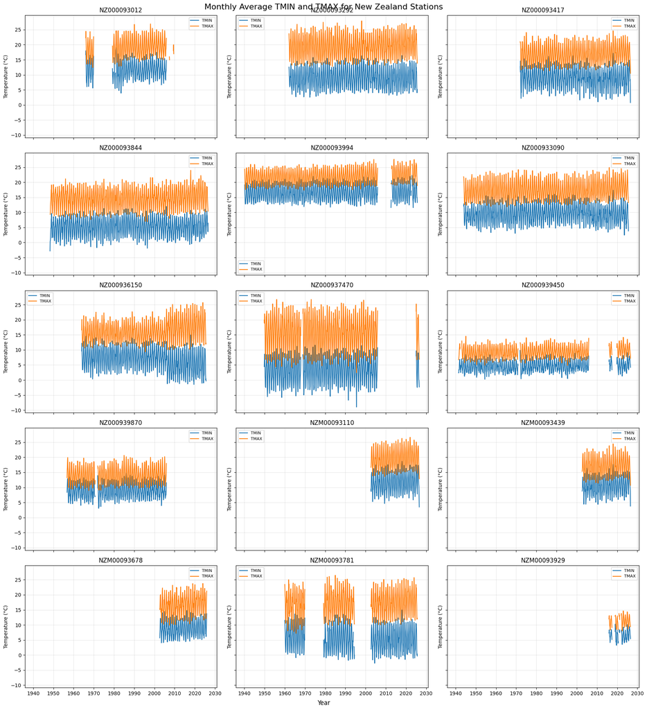

```python
import matplotlib.pyplot as plt

# Get the station IDs in a consistent order
station_ids = sorted(
    nz_monthly_aligned["ID"].unique()
)

# Create 5 x 3 subplot layout
fig, axes = plt.subplots(
    nrows=5,
    ncols=3,
    figsize=(18, 20),
    sharex=True,
    sharey=True
)

# Flatten the axes so we can loop through them
axes = axes.flatten()

for ax, station_id in zip(axes, station_ids):

    station_data = nz_monthly_aligned[
        nz_monthly_aligned["ID"] == station_id
    ]

    ax.plot(
        station_data["YEAR_MONTH"],
        station_data["TMIN"],
        label="TMIN"
    )

    ax.plot(
        station_data["YEAR_MONTH"],
        station_data["TMAX"],
        label="TMAX"
    )

    ax.set_title(station_id)
    ax.set_ylabel("Temperature (°C)")
    ax.grid(True, alpha=0.3)

# Put legend on each subplot
for ax in axes:
    ax.legend(fontsize=8)

# Common x-axis label
fig.supxlabel("Year")

# Overall figure title
fig.suptitle(
    "Monthly Average TMIN and TMAX for New Zealand Stations",
    fontsize=16
)

plt.tight_layout()
plt.show()
```

### Replotting using 12-month rolling average

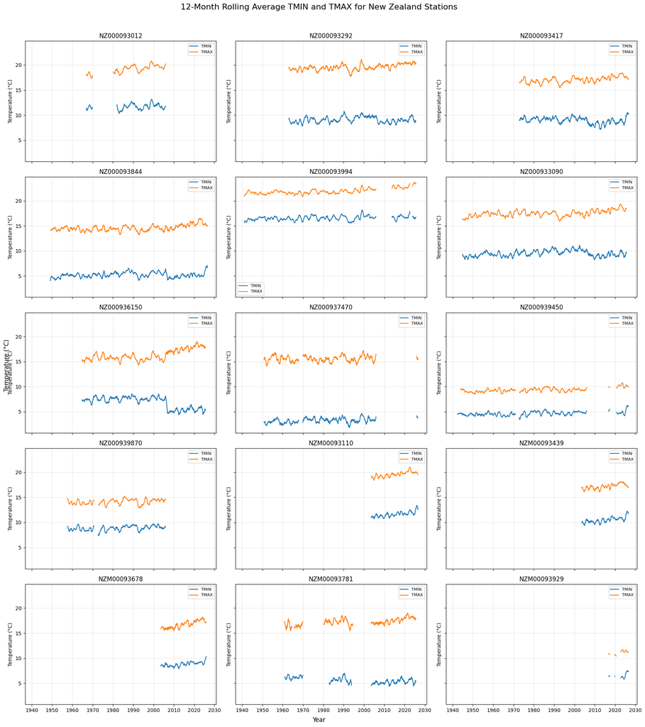

```python
import matplotlib.pyplot as plt

fig, axes = plt.subplots(
    nrows=5,
    ncols=3,
    figsize=(18, 20),
    sharex=True,
    sharey=True
)

axes = axes.flatten()

for ax, station_id in zip(axes, station_ids):

    station_data = (
        nz_monthly_aligned[
            nz_monthly_aligned["ID"] == station_id
        ]
        .sort_values("YEAR_MONTH")
        .copy()
    )

    # 12-month rolling averages
    station_data["TMIN_SMOOTH"] = (
        station_data["TMIN"]
        .rolling(window=12, min_periods=12)
        .mean()
    )

    station_data["TMAX_SMOOTH"] = (
        station_data["TMAX"]
        .rolling(window=12, min_periods=12)
        .mean()
    )

    ax.plot(
        station_data["YEAR_MONTH"],
        station_data["TMIN_SMOOTH"],
        label="TMIN"
    )

    ax.plot(
        station_data["YEAR_MONTH"],
        station_data["TMAX_SMOOTH"],
        label="TMAX"
    )

    ax.set_title(station_id)
    ax.set_ylabel("Temperature (°C)")
    ax.grid(True, alpha=0.3)
    ax.legend(fontsize=8)

fig.supxlabel("Year")
fig.supylabel("Temperature (°C)")

fig.suptitle(
    "12-Month Rolling Average TMIN and TMAX for New Zealand Stations",
    fontsize=16,
    y=0.995
)

plt.tight_layout(rect=[0, 0, 1, 0.98])
plt.show()
```

**What the figure shows**

A few useful observations:

1. The TMAX line is consistently above TMIN, as expected.
2. Stations have noticeably different temperature levels, reflecting their different locations.
3. Some stations have much shorter periods of available data than others.
4. There are clear gaps in several station records, and these have been preserved rather than filled with artificial values.
5. The 12-month smoothing removes most of the strong month-to-month seasonal oscillation and makes longer-term changes easier to compare.
6. Using the same x- and y-axis scales across the subplots makes the stations directly comparable.

**One methodological point for report**

The observations were aggregated to monthly averages and then smoothed using a 12-month rolling mean. This reduced the strong short-term seasonal variation and made longer-term patterns between stations easier to compare. Missing observations were retained as gaps rather than being interpolated, so the visualisation does not imply data was available when it was not. All stations were aligned to the same monthly time axis and plotted using common temperature and time scales. That directly addresses all three things the question asks you to consider:

1. Smoothing: monthly aggregation + 12-month rolling average
2. Gaps: retained as missing values
3. Alignment: common time and temperature scales

## Question 1: Part (c)

### Calculating the country-wide monthly averages

```python
country_monthly = (
    nz_monthly_pd
    .groupby("YEAR_MONTH")[["TMIN", "TMAX"]]
    .mean()
    .reset_index()
    .sort_values("YEAR_MONTH")
)

country_monthly.head()
```

|  | YEAR_MONTH | TMIN | TMAX |
| --- | --- | --- | --- |
| 0 | 1940-03-01 | 19.145833 | 24.370833 |
| 1 | 1940-04-01 | 16.176667 | 22.033333 |
| 2 | 1940-05-01 | 15.158065 | 20.232258 |
| 3 | 1940-06-01 | 12.890000 | 18.330000 |
| 4 | 1940-07-01 | 12.748387 | 17.548387 |

### Creating 12-month smoothing

```python
country_monthly["TMIN_SMOOTH"] = (
    country_monthly["TMIN"]
    .rolling(window=12, min_periods=12)
    .mean()
)

country_monthly["TMAX_SMOOTH"] = (
    country_monthly["TMAX"]
    .rolling(window=12, min_periods=12)
    .mean()
)

country_monthly.head(15)
```

|  | YEAR_MONTH | TMIN | TMAX | TMIN_SMOOTH | TMAX_SMOOTH |
| --- | --- | --- | --- | --- | --- |
| 0 | 1940-03-01 | 19.145833 | 24.370833 | NaN | NaN |
| 1 | 1940-04-01 | 16.176667 | 22.033333 | NaN | NaN |
| 2 | 1940-05-01 | 15.158065 | 20.232258 | NaN | NaN |
| 3 | 1940-06-01 | 12.890000 | 18.330000 | NaN | NaN |
| 4 | 1940-07-01 | 12.748387 | 17.548387 | NaN | NaN |
| 5 | 1940-08-01 | 13.154839 | 17.725806 | NaN | NaN |
| 6 | 1940-09-01 | 12.946667 | 18.763333 | NaN | NaN |
| 7 | 1940-10-01 | 14.438710 | 19.890323 | NaN | NaN |
| 8 | 1940-11-01 | 15.026667 | 20.533333 | NaN | NaN |
| 9 | 1940-12-01 | 17.261290 | 22.541935 | NaN | NaN |
| 10 | 1941-01-01 | 19.461290 | 24.367742 | NaN | NaN |
| 11 | 1941-02-01 | 19.803571 | 24.778571 | 15.684332 | 20.926321 |
| 12 | 1941-03-01 | 19.022581 | 24.638710 | 15.674061 | 20.948644 |
| 13 | 1941-04-01 | 18.180000 | 22.910000 | 15.841006 | 21.021700 |
| 14 | 1941-05-01 | 15.512903 | 21.193548 | 15.870575 | 21.101807 |

### Ploting country-wide TMIN and TMAX

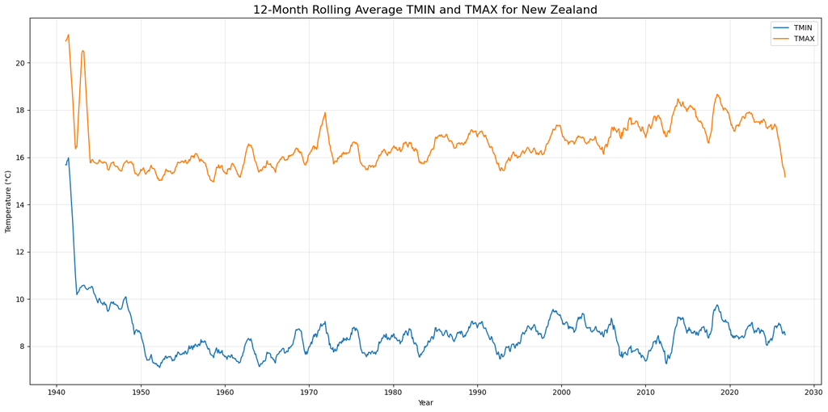

```python
import matplotlib.pyplot as plt

fig, ax = plt.subplots(figsize=(16, 8))

ax.plot(
    country_monthly["YEAR_MONTH"],
    country_monthly["TMIN_SMOOTH"],
    label="TMIN"
)

ax.plot(
    country_monthly["YEAR_MONTH"],
    country_monthly["TMAX_SMOOTH"],
    label="TMAX"
)

ax.set_title(
    "12-Month Rolling Average TMIN and TMAX for New Zealand",
    fontsize=16
)

ax.set_xlabel("Year")
ax.set_ylabel("Temperature (°C)")

ax.grid(True, alpha=0.3)
ax.legend()

plt.tight_layout()
plt.show()
```

The country-wide time series shows that TMAX remains consistently higher than TMIN throughout the period. After the early part of the record, both series show noticeable variation over time, but the overall pattern suggests a gradual increase in temperatures in the later part of the dataset. The TMIN series generally stays around 7–10°C, while TMAX is mostly between about 15–19°C. There are also several shorter-term increases and decreases, particularly from the 1990s onwards. The 12-month rolling average makes these longer-term patterns easier to see by reducing the strong seasonal variation that would otherwise dominate the plot.

### Saving the final country-wide dataset

```python
# Save country-wide monthly averages and smoothed values

country_monthly_spark = spark.createDataFrame(country_monthly)

COUNTRY_MONTHLY_OUTPUT = (
    f"{OUTPUT_PATH}/nz_country_monthly_tmin_tmax"
)

country_monthly_spark.write.mode("overwrite").parquet(
    COUNTRY_MONTHLY_OUTPUT
)

print("Saved to:")
print(COUNTRY_MONTHLY_OUTPUT)b
```

```
Saved to:
wasbs://campus-user@madsstorage002.blob.core.windows.net/ama778/nz_country_monthly_tmin_tmax
```

```
26/09/02 14:16:38 WARN AzureFileSystemThreadPoolExecutor: Disabling threads for Delete operation as thread count 0 is <= 1
```

```python
country_monthly_saved = spark.read.parquet(
    COUNTRY_MONTHLY_OUTPUT
)

print("Saved rows:", country_monthly_saved.count())
country_monthly_saved.printSchema()
```

```
Saved rows: 1038
root
 |-- YEAR_MONTH: timestamp (nullable = true)
 |-- TMIN: double (nullable = true)
 |-- TMAX: double (nullable = true)
 |-- TMIN_SMOOTH: double (nullable = true)
 |-- TMAX_SMOOTH: double (nullable = true)
```

# Question 2: (Visualisation)

## Defining the paths

```python
STATIONS_OUTPUT = f"{OUTPUT_PATH}/stations_final"

print(STATIONS_OUTPUT)
```

```
wasbs://campus-user@madsstorage002.blob.core.windows.net/ama778/stations_final
```

## Loading the processed stations dataset

### Defining daily paths

```python
# Daily data available for this assignment
# 1750 is excluded because of known data-quality issues.
# Data resumes at 1763.

years = list(range(1763, 2027))

daily_paths = [
    f"{DAILY_PATH}/{year}.csv.gz"
    for year in years
]

print("Number of yearly files:", len(daily_paths))
print("First 3:", daily_paths[:3])
print("Last 3:", daily_paths[-3:])
```

```
Number of yearly files: 264
First 3: ['wasbs://campus-data@madsstorage002.blob.core.windows.net/ghcnd/daily/1763.csv.gz', 'wasbs://campus-data@madsstorage002.blob.core.windows.net/ghcnd/daily/1764.csv.gz', 'wasbs://campus-data@madsstorage002.blob.core.windows.net/ghcnd/daily/1765.csv.gz']
Last 3: ['wasbs://campus-data@madsstorage002.blob.core.windows.net/ghcnd/daily/2024.csv.gz', 'wasbs://campus-data@madsstorage002.blob.core.windows.net/ghcnd/daily/2025.csv.gz', 'wasbs://campus-data@madsstorage002.blob.core.windows.net/ghcnd/daily/2026.csv.gz']
```

## Question 2: Part (a)

### Loading the daily data & stations data

```python
# Loading the stations dataset

STATIONS_PATH = (
    f"wasbs://{azure_user_container_name}"
    f"@{azure_account_name}.blob.core.windows.net/"
    f"{username}/stations_final"
)

print(STATIONS_PATH)

stations = spark.read.parquet(STATIONS_PATH)

stations.printSchema()
stations.show(10, truncate = False)
```

```
wasbs://campus-user@madsstorage002.blob.core.windows.net/ama778/stations_final
```

```
root
 |-- ID: string (nullable = true)
 |-- LATITUDE: double (nullable = true)
 |-- LONGITUDE: double (nullable = true)
 |-- ELEVATION: double (nullable = true)
 |-- STATE: string (nullable = true)
 |-- NAME: string (nullable = true)
 |-- GSN_FLAG: string (nullable = true)
 |-- HCN_CRN_FLAG: string (nullable = true)
 |-- WMO_ID: string (nullable = true)
 |-- COUNTRY_NAME: string (nullable = true)
 |-- STATE_NAME: string (nullable = true)
 |-- ELEMENTS: array (nullable = true)
 |    |-- element: string (containsNull = true)
 |-- FIRST_YEAR: integer (nullable = true)
 |-- LAST_YEAR: integer (nullable = true)
 |-- ACTIVE_2026: boolean (nullable = true)
 |-- CORE_ELEMENT_COUNT: integer (nullable = true)
 |-- OTHER_ELEMENT_COUNT: integer (nullable = true)
 |-- COUNTRY_CODE: string (nullable = true)

+-----------+--------+---------+---------+-----+-----------------------------+--------+------------+------+-------------+--------------+------------------------------------------------------------------------------------------------------------------------+----------+---------+-----------+----------…
|ID         |LATITUDE|LONGITUDE|ELEVATION|STATE|NAME                         |GSN_FLAG|HCN_CRN_FLAG|WMO_ID|COUNTRY_NAME |STATE_NAME    |ELEMENTS                                                                                                                |FIRST_YEAR|LAST_YEAR|ACTIVE_2026|CORE_ELEME…
+-----------+--------+---------+---------+-----+-----------------------------+--------+------------+------+-------------+--------------+------------------------------------------------------------------------------------------------------------------------+----------+---------+-----------+----------…
|USC00314040|35.1    |-83.0833 |1066.8   |NC   |HIGH HAMPTON                 |        |            |      |United States|NORTH CAROLINA|[TMAX, TMIN, PRCP, SNWD, SNOW]                                                                                          |1932      |1935     |false      |5         …
|US009052008|43.7333 |-96.6333 |482.0    |SD   |SIOUX FALLS (ENVIRON. CANADA)|        |            |      |United States|SOUTH DAKOTA  |[TMAX, TMIN, PRCP, SNWD]                                                                                                |2008      |2016     |false      |4         …
|USC00314448|35.4    |-83.2833 |586.1    |NC   |JACK COVE                    |        |            |      |United States|NORTH CAROLINA|[PRCP, SNWD, MDPR, DAPR, SNOW]                                                                                          |1949      |1962     |false      |3         …
|US10adam003|40.4663 |-98.6537 |615.1    |NE   |HOLSTEIN 0.1 NW              |        |            |      |United States|NEBRASKA      |[PRCP, SNWD, SNOW, WESF]                                                                                                |2004      |2010     |false      |3         …
|USC00314615|34.9667 |-77.95   |18.3     |NC   |KENANSVILLE                  |        |            |      |United States|NORTH CAROLINA|[TMAX, TMIN, PRCP, SNOW, TOBS, WT08, WT16]                                                                              |1922      |1937     |false      |4         …
|US10adam004|40.4798 |-98.4026 |570.0    |NE   |AYR 3.5 NE                   |        |            |      |United States|NEBRASKA      |[PRCP, SNWD, SNOW, WESF]                                                                                                |2004      |2022     |false      |3         …
|USC00314643|36.35   |-81.1833 |804.7    |NC   |KILBY'S GAP (1)              |        |            |      |United States|NORTH CAROLINA|[TMAX, TMIN, PRCP, SNWD, SNOW, TOBS, WT16, WT01]                                                                        |1938      |1947     |false      |5         …
|US10adam007|40.5389 |-98.4713 |588.9    |NE   |HASTINGS 5.4 WSW             |        |            |      |United States|NEBRASKA      |[PRCP, SNWD, SNOW]                                                                                                      |2004      |2019     |false      |3         …
|USC00314684|35.1967 |-77.5433 |7.3      |NC   |KINSTON 7 SE                 |        |HCN         |      |United States|NORTH CAROLINA|[WT07, TMAX, TMIN, PRCP, SNWD, MDPR, SNOW, TOBS, WT11, WT01, MDSF, WT09, WT05, WT04, DAPR, WT14, WT08, WT16, WT06, WT03]|1899      |2018     |false      |5         …
|US10adam008|40.4953 |-98.2973 |566.9    |NE   |GLENVIL 2.3 WSW              |        |            |      |United States|NEBRASKA      |[PRCP, SNWD, SNOW, WESF]                                                                                                |2004      |2026     |true       |3         …
+-----------+--------+---------+---------+-----+-----------------------------+--------+------------+------+-------------+--------------+------------------------------------------------------------------------------------------------------------------------+----------+---------+-----------+----------…
only showing top 10 rows
```

```python
# Load the 264 daily files
daily_all = spark.read.text(daily_paths)

print("Daily data loaded.")
daily_all.printSchema()
```

```
Daily data loaded.
root
 |-- value: string (nullable = true)
```

### Parsing the required fields

```python
from pyspark.sql.functions import split, col

daily_parsed = daily_all.select(
    split(col("value"), ",").getItem(0).alias("ID"),
    split(col("value"), ",").getItem(1).alias("DATE"),
    split(col("value"), ",").getItem(2).alias("ELEMENT"),
    split(col("value"), ",").getItem(3).cast("double").alias("VALUE")
)

daily_parsed.printSchema()
daily_parsed.show(5, truncate=False)
```

```
root
 |-- ID: string (nullable = true)
 |-- DATE: string (nullable = true)
 |-- ELEMENT: string (nullable = true)
 |-- VALUE: double (nullable = true)

+-----------+--------+-------+-----+
|ID         |DATE    |ELEMENT|VALUE|
+-----------+--------+-------+-----+
|US1ALJF0004|20100101|PRCP   |5.0  |
|US1ALJF0007|20100101|PRCP   |8.0  |
|US1ALJF0011|20100101|PRCP   |8.0  |
|US1ALJF0024|20100101|PRCP   |8.0  |
|US1ALJF0025|20100101|PRCP   |15.0 |
+-----------+--------+-------+-----+
only showing top 5 rows
```

### Filtering to precipitation only

```python
prcp = daily_parsed.filter(
    col("ELEMENT") == "PRCP"
)

prcp.show(5, truncate=False)
```

```
+-----------+--------+-------+-----+
|ID         |DATE    |ELEMENT|VALUE|
+-----------+--------+-------+-----+
|US1ALJF0004|20100101|PRCP   |5.0  |
|US1ALJF0007|20100101|PRCP   |8.0  |
|US1ALJF0011|20100101|PRCP   |8.0  |
|US1ALJF0024|20100101|PRCP   |8.0  |
|US1ALJF0025|20100101|PRCP   |15.0 |
+-----------+--------+-------+-----+
only showing top 5 rows
```

### Creating the station -> country lookup.

```python
station_country = (
    stations
    .select("ID", "COUNTRY_NAME")
    .filter(col("COUNTRY_NAME").isNotNull())
    .dropDuplicates(["ID"])
)

station_country.show(5, truncate=False)
```

```
[Stage 28:==================================================>       (7 + 1) / 8]
```

```
+-----------+--------------------+
|ID         |COUNTRY_NAME        |
+-----------+--------------------+
|ACW00011604|Antigua and Barbuda |
|ACW00011647|Antigua and Barbuda |
|AE000041196|United Arab Emirates|
|AEM00041194|United Arab Emirates|
|AEM00041217|United Arab Emirates|
+-----------+--------------------+
only showing top 5 rows
```

### Joining precipitation to countries

```python
prcp_country = (
    prcp
    .join(
        station_country,
        on="ID",
        how="inner"
    )
)

prcp_country.show(5, truncate=False)
```

```
+-----------+--------+-------+-----+-------------+
|ID         |DATE    |ELEMENT|VALUE|COUNTRY_NAME |
+-----------+--------+-------+-----+-------------+
|US1ALJF0004|20100101|PRCP   |5.0  |United States|
|US1ALJF0007|20100101|PRCP   |8.0  |United States|
|US1ALJF0011|20100101|PRCP   |8.0  |United States|
|US1ALJF0024|20100101|PRCP   |8.0  |United States|
|US1ALJF0025|20100101|PRCP   |15.0 |United States|
+-----------+--------+-------+-----+-------------+
only showing top 5 rows
```

### Extracting the year and aggregating

```python
from pyspark.sql.functions import substring, avg

rainfall_year_country = (
    prcp_country
    .select(
        "COUNTRY_NAME",
        substring(col("DATE"), 1, 4).alias("YEAR"),
        "VALUE"
    )
    .groupBy("YEAR", "COUNTRY_NAME")
    .agg(
        avg("VALUE").alias("AVG_DAILY_RAINFALL")
    )
    .orderBy("YEAR", "COUNTRY_NAME")
)

rainfall_year_country.show(20, truncate=False)
```

```
[Stage 38:=====================================================>(107 + 1) / 108]
```

```
+----+------------+------------------+
|YEAR|COUNTRY_NAME|AVG_DAILY_RAINFALL|
+----+------------+------------------+
|1781|Germany     |24.55890410958904 |
|1782|Germany     |13.712328767123287|
|1783|Germany     |17.832876712328765|
|1784|Germany     |16.57650273224044 |
|1785|Germany     |16.16986301369863 |
|1786|Germany     |24.167123287671235|
|1789|Germany     |18.476712328767125|
|1790|Germany     |15.501369863013698|
|1791|Germany     |17.4756446991404  |
|1792|Germany     |18.117486338797814|
|1794|Germany     |20.753424657534246|
|1795|Germany     |14.487671232876712|
|1796|Germany     |14.44475138121547 |
|1797|Germany     |15.95068493150685 |
|1797|Italy       |12.446575342465753|
|1798|Germany     |16.65753424657534 |
|1798|Italy       |13.408219178082192|
|1800|Germany     |16.016438356164382|
|1801|Germany     |19.416438356164385|
|1802|Germany     |12.334246575342465|
+----+------------+------------------+
only showing top 20 rows
```

### Saving the result

```python
RAIN_YEAR_COUNTRY_OUTPUT = (
    f"{OUTPUT_PATH}/rainfall_year_country"
)

rainfall_year_country.write.mode("overwrite").parquet(
    RAIN_YEAR_COUNTRY_OUTPUT
)

print("Saved to:")
print(RAIN_YEAR_COUNTRY_OUTPUT)
```

```
26/09/08 13:41:50 WARN AzureFileSystemThreadPoolExecutor: Disabling threads for Delete operation as thread count 0 is <= 1
```

```
Saved to:
wasbs://campus-user@madsstorage002.blob.core.windows.net/ama778/rainfall_year_country
```

```
26/09/08 13:41:51 WARN AzureFileSystemThreadPoolExecutor: Disabling threads for Delete operation as thread count 0 is <= 1
```

```python
rainfall_year_country_saved = spark.read.parquet(
    RAIN_YEAR_COUNTRY_OUTPUT
)

print(
    "Aggregated rows:",
    rainfall_year_country_saved.count()
)

rainfall_year_country_saved.printSchema()
```

```
Aggregated rows: 17789
root
 |-- YEAR: string (nullable = true)
 |-- COUNTRY_NAME: string (nullable = true)
 |-- AVG_DAILY_RAINFALL: double (nullable = true)
```

### Calculating descriptive statistics

```python
# Descriptive statistics for average daily rainfall

rainfall_stats = (
    rainfall_year_country_saved
    .select("AVG_DAILY_RAINFALL")
    .describe()
)

# Convert rainfall from tenths of mm to mm/day
rainfall_year_country_mm = (
    rainfall_year_country_saved
    .withColumn(
        "AVG_DAILY_RAINFALL_MM",
        col("AVG_DAILY_RAINFALL") / 10
    )
)

rainfall_year_country_mm.select(
    "AVG_DAILY_RAINFALL_MM"
).describe().show()
```

```
+-------+---------------------+
|summary|AVG_DAILY_RAINFALL_MM|
+-------+---------------------+
|  count|                17789|
|   mean|   4.1961787952351965|
| stddev|     8.41922789253786|
|    min|                  0.0|
|    max|                436.1|
+-------+---------------------+
```

```python
rainfall_year_country_mm.orderBy(
    col("AVG_DAILY_RAINFALL_MM").desc()
).show(1)
```

```
+----+-----------------+------------------+---------------------+
|YEAR|     COUNTRY_NAME|AVG_DAILY_RAINFALL|AVG_DAILY_RAINFALL_MM|
+----+-----------------+------------------+---------------------+
|2000|Equatorial Guinea|            4361.0|                436.1|
+----+-----------------+------------------+---------------------+
only showing top 1 row
```

### Find the country-year with the highest average daily rainfall

```python
highest_rainfall = (
    rainfall_year_country_mm
    .orderBy(col("AVG_DAILY_RAINFALL").desc())
    .limit(10)
)

highest_rainfall.show(10, truncate=False)
```

```
+----+------------------+------------------+---------------------+
|YEAR|COUNTRY_NAME      |AVG_DAILY_RAINFALL|AVG_DAILY_RAINFALL_MM|
+----+------------------+------------------+---------------------+
|2000|Equatorial Guinea |4361.0            |436.1                |
|1975|Dominican Republic|3414.0            |341.4                |
|1974|Laos              |2480.5            |248.05               |
|1978|Belize            |2244.714285714286 |224.4714285714286    |
|1979|Sint Maarten      |1967.0            |196.7                |
|1974|Costa Rica        |1820.0            |182.0                |
|1979|Belize            |1755.5454545454545|175.55454545454546   |
|1973|Suriname          |1710.0            |171.0                |
|1978|Curacao           |1675.0384615384614|167.50384615384615   |
|1977|Belize            |1541.7142857142858|154.17142857142858   |
+----+------------------+------------------+---------------------+
```

we don't want to blindly report the single maximum. Looking at the top 10 will help us determine whether the maximum is a plausible rainfall value or whether there is an obvious outlier/data-quality issue.

### Investigating suspicious rainfall values

```python
equatorial_guinea_stations = (
    stations
    .filter(col("COUNTRY_NAME") == "Equatorial Guinea")
    .select(
        "ID",
        "NAME",
        "COUNTRY_NAME",
        "FIRST_YEAR",
        "LAST_YEAR",
        "ELEMENTS"
    )
    .dropDuplicates(["ID"])
)

equatorial_guinea_stations.show(
    50,
    truncate=False
)
```

```
[Stage 68:=====================>                                    (3 + 5) / 8]
```

```
+-----------+---------------+-----------------+----------+---------+------------------------+
|ID         |NAME           |COUNTRY_NAME     |FIRST_YEAR|LAST_YEAR|ELEMENTS                |
+-----------+---------------+-----------------+----------+---------+------------------------+
|EKM00064810|MALABO         |Equatorial Guinea|1996      |2025     |[TMAX, TMIN, PRCP, TAVG]|
|EKM00064820|BATA (RIO MUNI)|Equatorial Guinea|2007      |2026     |[TMAX, TMIN, PRCP, TAVG]|
+-----------+---------------+-----------------+----------+---------+------------------------+
```

```python
daily_2000 = spark.read.text(
    f"{DAILY_PATH}/2000.csv.gz"
)

daily_2000_parsed = daily_2000.select(
    split(col("value"), ",").getItem(0).alias("ID"),
    split(col("value"), ",").getItem(1).alias("DATE"),
    split(col("value"), ",").getItem(2).alias("ELEMENT"),
    split(col("value"), ",").getItem(3).cast("double").alias("VALUE")
)
```

```python
eg_prcp_2000 = (
    daily_2000_parsed
    .join(
        equatorial_guinea_stations.select("ID"),
        on="ID",
        how="inner"
    )
    .filter(col("ELEMENT") == "PRCP")
)

eg_prcp_2000.show(
    30,
    truncate=False
)
```

```
[Stage 74:>                                                         (0 + 1) / 1]
```

```
+-----------+--------+-------+------+
|ID         |DATE    |ELEMENT|VALUE |
+-----------+--------+-------+------+
|EKM00064810|20000622|PRCP   |4361.0|
+-----------+--------+-------+------+
```

```python
eg_prcp_2000.count()
```

```
1
```

```python
eg_prcp_2000.groupBy("ID").count().show()
```

```
[Stage 83:>                                                         (0 + 1) / 1]
```

```
+-----------+-----+
|         ID|count|
+-----------+-----+
|EKM00064810|    1|
+-----------+-----+
```

```
Number of country-year observations: 17,789
Mean average daily rainfall: 41.96
Standard deviation: 84.19
Minimum: 0.0
Maximum: 4361.0 raw units = 436.1 mm
Highest country-year: Equatorial Guinea, 2000
Number of underlying PRCP observations: 1
Station: Malabo (EKM00064810)
Date: 22 June 2000
```

**Interpretation**

The maximum is not a sensible representation of Equatorial Guinea's average daily rainfall for 2000, because the country-year estimate is based on only one precipitation observation. While 436.1 mm of rainfall on a single day can occur as an extreme rainfall event, using that one observation as the annual average gives a highly misleading result. This demonstrates how sparse observations can create extreme country-year averages.

## Question 2: Part (b)

```python
# Verify the raw daily dataset used for Q2(a)

raw_daily_count = daily_all.count()

print("Raw daily records used:", raw_daily_count)
print("Approximately 3.19 billion:", raw_daily_count == 3190161793)
```

```
[Stage 86:=====================================================>(107 + 1) / 108]
```

```
Raw daily records used: 3190161793
Approximately 3.19 billion: True
```

```python
prcp_count = (
    daily_parsed
    .filter(col("ELEMENT") == "PRCP")
    .count()
)

print("Raw daily records:", raw_daily_count)
print("PRCP observations:", prcp_count)
```

```
[Stage 89:=====================================================>(107 + 1) / 108]
```

```
Raw daily records: 3190161793
PRCP observations: 1095197420
```

Importantly, 17,789 is not being produced from a small subset of the dataset. The aggregation starts from the full 3.19 billion raw daily records, then selects the ~1.095 billion precipitation observations. The logic is therefore:

```
3,190,161,793 daily observations
              │
              ▼
        Parse daily data
              │
              ▼
     Filter ELEMENT = PRCP
              │
              ▼
      1,095,197,420 PRCP
              │
              ▼
   Group by YEAR + COUNTRY_NAME
              │
              ▼
          17,789 rows
```

### Loading the dataset

```python
OUTPUT_PATH = (
    f"wasbs://{azure_user_container_name}"
    f"@{azure_account_name}.blob.core.windows.net/"
    f"{username}"
)

print(OUTPUT_PATH)
print(username)
```

```
wasbs://campus-user@madsstorage002.blob.core.windows.net/ama778
ama778
```

```python
!hdfs dfs -ls "$OUTPUT_PATH"
```

```
Found 9 items
-rwxrwxrwx   1                            6 2026-07-22 09:16 wasbs://campus-user@madsstorage002.blob.core.windows.net/ama778/ama778
drwxr-xr-x   - ama778 supergroup          0 2026-08-13 17:09 wasbs://campus-user@madsstorage002.blob.core.windows.net/ama778/enriched_stations
drwxr-xr-x   - ama778 supergroup          0 2026-09-02 14:16 wasbs://campus-user@madsstorage002.blob.core.windows.net/ama778/nz_country_monthly_tmin_tmax
drwxr-xr-x   - ama778 supergroup          0 2026-09-02 14:16 wasbs://campus-user@madsstorage002.blob.core.windows.net/ama778/nz_monthly_tmin_tmax
drwxr-xr-x   - ama778 supergroup          0 2026-09-07 16:55 wasbs://campus-user@madsstorage002.blob.core.windows.net/ama778/nz_station_pair_distances
drwxr-xr-x   - ama778 supergroup          0 2026-09-08 13:41 wasbs://campus-user@madsstorage002.blob.core.windows.net/ama778/rainfall_year_country
drwxr-xr-x   - ama778 supergroup          0 2026-09-04 16:34 wasbs://campus-user@madsstorage002.blob.core.windows.net/ama778/rainfall_year_country_mm
drwxr-xr-x   - ama778 supergroup          0 2026-08-11 13:22 wasbs://campus-user@madsstorage002.blob.core.windows.net/ama778/stations
drwxr-xr-x   - ama778 supergroup          0 2026-08-21 12:20 wasbs://campus-user@madsstorage002.blob.core.windows.net/ama778/stations_final
```

```python
# Path to the saved Q2(a) country-year rainfall dataset
RAIN_YEAR_COUNTRY_OUTPUT = (
    f"{OUTPUT_PATH}/rainfall_year_country"
)

print("Loading from:")
print(RAIN_YEAR_COUNTRY_OUTPUT)

rainfall_year_country = spark.read.parquet(
    RAIN_YEAR_COUNTRY_OUTPUT
)

print("Rows:", rainfall_year_country.count())
rainfall_year_country.printSchema()
```

```
Loading from:
wasbs://campus-user@madsstorage002.blob.core.windows.net/ama778/rainfall_year_country
Rows: 17789
root
 |-- YEAR: string (nullable = true)
 |-- COUNTRY_NAME: string (nullable = true)
 |-- AVG_DAILY_RAINFALL: double (nullable = true)
```

### Extracting 2025 data

```python
from pyspark.sql.functions import col

rainfall_2025 = (
    rainfall_year_country
    .filter(col("YEAR") == "2025")
    .orderBy(col("AVG_DAILY_RAINFALL").desc())
)

print("2025 country-year rows:", rainfall_2025.count())

rainfall_2025.show(50, truncate = False)
```

```
2025 country-year rows: 172
+----+------------------------------+------------------+
|YEAR|COUNTRY_NAME                  |AVG_DAILY_RAINFALL|
+----+------------------------------+------------------+
|2025|Azerbaijan                    |540.0             |
|2025|Angola                        |347.0             |
|2025|Congo (Kinshasa)              |182.88888888888889|
|2025|Indonesia                     |164.70023419203747|
|2025|Wallis and Futuna [France]    |151.69230769230768|
|2025|Guinea                        |145.2336448598131 |
|2025|Korea, North                  |145.0423076923077 |
|2025|American Samoa [United States]|136.3095890410959 |
|2025|Gambia, The                   |134.5             |
|2025|Brunei                        |119.6020942408377 |
|2025|India                         |112.53444259567388|
|2025|Philippines                   |110.7320028510335 |
|2025|Saudi Arabia                  |110.57692307692308|
|2025|Singapore                     |108.43373493975903|
|2025|Nigeria                       |105.53246753246754|
|2025|Burma                         |104.51231527093596|
|2025|Venezuela                     |103.4074074074074 |
|2025|Federated States of Micronesia|102.41247169482669|
|2025|Palau                         |101.77859778597787|
|2025|Bangladesh                    |100.4167862266858 |
|2025|Vanuatu                       |99.89437819420783 |
|2025|Paraguay                      |97.98666666666666 |
|2025|Suriname                      |96.29032258064517 |
|2025|Tanzania                      |95.1304347826087  |
|2025|Laos                          |92.9896265560166  |
|2025|Solomon Islands               |92.41836734693878 |
|2025|Malaysia                      |88.22001282873637 |
|2025|Madagascar                    |87.92012288786482 |
|2025|Tajikistan                    |87.80662020905923 |
|2025|Kyrgyzstan                    |87.66237942122187 |
|2025|Tuvalu                        |83.30147058823529 |
|2025|Cameroon                      |82.39066339066339 |
|2025|Thailand                      |81.66009615384615 |
|2025|El Salvador                   |79.87096774193549 |
|2025|Costa Rica                    |79.42512077294685 |
|2025|Bolivia                       |78.66079703429101 |
|2025|Mozambique                    |76.92015209125475 |
|2025|Ethiopia                      |76.11864406779661 |
|2025|Vietnam                       |74.97643979057591 |
|2025|Fiji                          |73.4496062992126  |
|2025|Guyana                        |73.1642228739003  |
|2025|Mayotte [France]              |71.04347826086956 |
|2025|Maldives                      |70.78695652173913 |
|2025|French Guiana [France]        |69.64285714285714 |
|2025|Rwanda                        |67.75471698113208 |
|2025|Sri Lanka                     |67.55652173913043 |
|2025|Moldova                       |66.40748031496064 |
|2025|Marshall Islands              |66.00868845676459 |
|2025|Uzbekistan                    |65.5575           |
|2025|Peru                          |65.21028466483011 |
+----+------------------------------+------------------+
only showing top 50 rows
```